# SAIS

# P10 : Taking photos or copies of the national ID card is not allowed, the needed data should be recorded after that the card must be returned immediately.

```python
SAIS.groupby(['Job_Status']).P10.value_counts()
```

```
Job_Status  P10
Employee    Aware & Follow      43
            Unaware             12
            Aware & Unfollow     6
Other       Aware & Follow      41
            Aware & Unfollow     8
            Unaware              2
Student     Aware & Follow      18
            Unaware              7
            Aware & Unfollow     6
Name: P10, dtype: int64
```

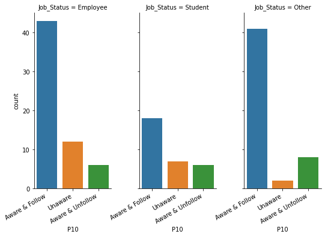

```python
chart=sns.catplot(x='P10', col='Job_Status', kind='count', data=SAIS, height=5, aspect=0.5,
                   order=SAIS['P10'].value_counts().index)
chart.set_xticklabels(rotation=30, horizontalalignment='right')
```

```python
SAIS.groupby(['Age']).P10.value_counts()
```

```
Age      P10
18 - 25  Aware & Follow      22
         Aware & Unfollow     5
         Unaware              5
26 - 35  Aware & Follow      29
         Aware & Unfollow     7
         Unaware              7
36 - 45  Aware & Follow      19
         Unaware              3
         Aware & Unfollow     1
46 - 60  Aware & Follow      32
         Aware & Unfollow     7
         Unaware              6
Name: P10, dtype: int64
```

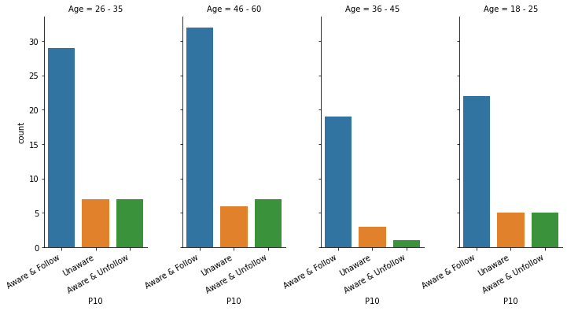

```python
chart=sns.catplot(x='P10', col='Age', kind='count', data=SAIS, height=5, aspect=0.5,
                   order=SAIS['P10'].value_counts().index)
chart.set_xticklabels(rotation=30, horizontalalignment='right')
```

```python
SAIS.groupby(['Gender']).P10.value_counts()
```

```
Gender  P10
Female  Aware & Follow      51
        Aware & Unfollow    11
        Unaware             11
Male    Aware & Follow      51
        Unaware             10
        Aware & Unfollow     9
Name: P10, dtype: int64
```

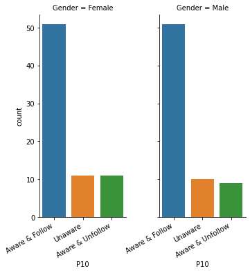

```python
chart=sns.catplot(x='P10', col='Gender', kind='count', data=SAIS, height=5, aspect=0.5,
                   order=SAIS['P10'].value_counts().index)
chart.set_xticklabels(rotation=30, horizontalalignment='right')
```

# P11: Companies must record the required data only, keeping data for long is not allowed unless it still in use and needed.

```python
SAIS.groupby(['Job_Status']).P11.value_counts()
```

```
Job_Status  P11
Employee    Aware & Follow      43
            Unaware             10
            Aware & Unfollow     8
Other       Aware & Follow      36
            Unaware             10
            Aware & Unfollow     5
Student     Aware & Follow      17
            Aware & Unfollow     9
            Unaware              5
Name: P11, dtype: int64
```

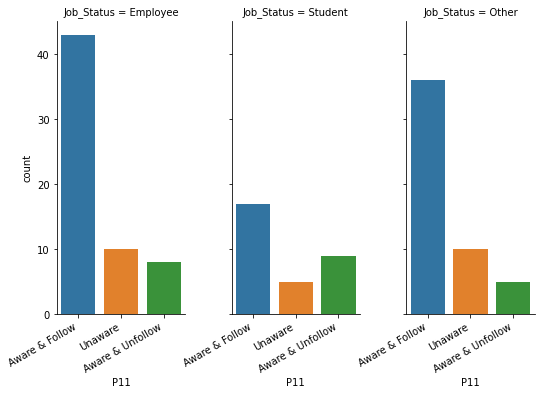

```python
chart=sns.catplot(x='P11', col='Job_Status', kind='count', data=SAIS, height=5, aspect=0.5,
                   order=SAIS['P11'].value_counts().index)
chart.set_xticklabels(rotation=30, horizontalalignment='right')
```

```python
SAIS.groupby(['Age']).P11.value_counts()
```

```
Age      P11
18 - 25  Aware & Follow      21
         Aware & Unfollow     7
         Unaware              4
26 - 35  Aware & Follow      26
         Unaware             11
         Aware & Unfollow     6
36 - 45  Aware & Follow      16
         Unaware              5
         Aware & Unfollow     2
46 - 60  Aware & Follow      33
         Aware & Unfollow     7
         Unaware              5
Name: P11, dtype: int64
```

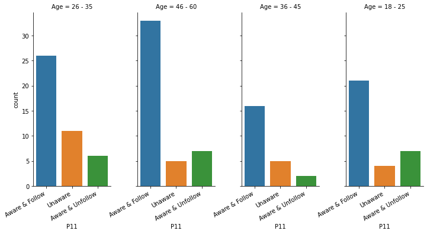

```python
chart=sns.catplot(x='P11', col='Age', kind='count', data=SAIS, height=5, aspect=0.5,
                   order=SAIS['P11'].value_counts().index)
chart.set_xticklabels(rotation=30, horizontalalignment='right')
```

```python
SAIS.groupby(['Gender']).P11.value_counts()
```

```
Gender  P11
Female  Aware & Follow      49
        Unaware             15
        Aware & Unfollow     9
Male    Aware & Follow      47
        Aware & Unfollow    13
        Unaware             10
Name: P11, dtype: int64
```

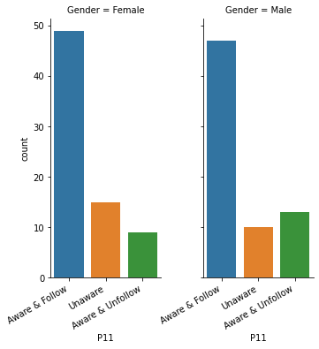

```python
chart=sns.catplot(x='P11', col='Gender', kind='count', data=SAIS, height=5, aspect=0.5,
                   order=SAIS['P11'].value_counts().index)
chart.set_xticklabels(rotation=30, horizontalalignment='right')
```

# P12: There are information policies in all sectors including companies, banks, and universities

```python
SAIS.groupby(['Job_Status']).P12.value_counts()
```

```
Job_Status  P12
Employee    Aware & Follow      54
            Aware & Unfollow     5
            Unaware              2
Other       Aware & Follow      40
            Aware & Unfollow     8
            Unaware              3
Student     Aware & Follow      21
            Aware & Unfollow     6
            Unaware              4
Name: P12, dtype: int64
```

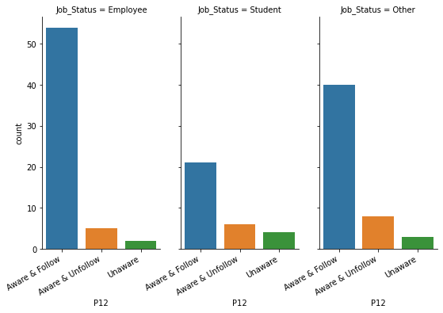

```python
chart=sns.catplot(x='P12', col='Job_Status', kind='count', data=SAIS, height=5, aspect=0.5,
                   order=SAIS['P12'].value_counts().index)
chart.set_xticklabels(rotation=30, horizontalalignment='right')
```

```python
SAIS.groupby(['Age']).P12.value_counts()
```

```
Age      P12
18 - 25  Aware & Follow      25
         Unaware              4
         Aware & Unfollow     3
26 - 35  Aware & Follow      34
         Aware & Unfollow     7
         Unaware              2
36 - 45  Aware & Follow      19
         Aware & Unfollow     3
         Unaware              1
46 - 60  Aware & Follow      37
         Aware & Unfollow     6
         Unaware              2
Name: P12, dtype: int64
```

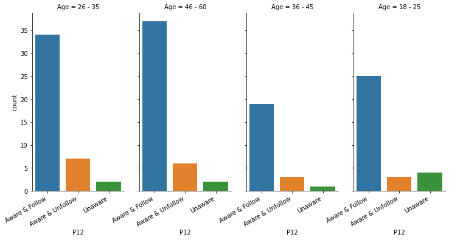

```python
chart=sns.catplot(x='P12', col='Age', kind='count', data=SAIS, height=5, aspect=0.5,
                   order=SAIS['P12'].value_counts().index)
chart.set_xticklabels(rotation=30, horizontalalignment='right')
```

```python
SAIS.groupby(['Gender']).P12.value_counts()
```

```
Gender  P12
Female  Aware & Follow      59
        Aware & Unfollow    10
        Unaware              4
Male    Aware & Follow      56
        Aware & Unfollow     9
        Unaware              5
Name: P12, dtype: int64
```

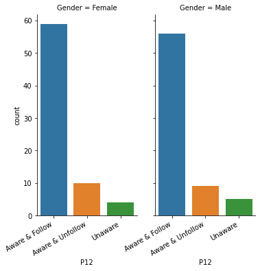

```python
chart=sns.catplot(x='P12', col='Gender', kind='count', data=SAIS, height=5, aspect=0.5,
                   order=SAIS['P12'].value_counts().index)
chart.set_xticklabels(rotation=30, horizontalalignment='right')
```